# Communicate Data Findings

## Preliminary Wrangling

> Prosper is San Francisco based peer-to-peer(P2P) lending company. PSP lending is a industry that matching and facilitating individuals borrowers and lenders. This kind of financial service is generally cheaper than traditional established financial institutions. For lender, this kind of platform generate higher return than saving or long-term investment in banks, and they also provide credit screening services. For borrowers, it’s easier to lend loan from a P2P platform, the administration process is less exhausting and less time consuming.

```python
# import all packages and set plots to be embedded inline
import numpy as np
import pandas as pd
import matplotlib.pyplot as plt
import seaborn as sb

%matplotlib inline
```

> Load in your dataset and describe its properties through the questions below. Try and motivate your exploration goals through this section.

```python
# Load csv and
df = pd.read_csv('prosperLoanData.csv')
```

```python
pd.set_option('display.max_columns', 81)
df.head()
```

|  | ListingKey | ListingNumber | ListingCreationDate | CreditGrade | Term | LoanStatus | ClosedDate | BorrowerAPR | BorrowerRate | LenderYield | EstimatedEffectiveYield | EstimatedLoss | EstimatedReturn | ProsperRating (numeric) | ProsperRating (Alpha) | ProsperScore | ListingCategory (numeric) | BorrowerState | Occupation | EmploymentStatus | EmploymentStatusDuration | IsBorrowerHomeowner | CurrentlyInGroup | GroupKey | DateCreditPulled | CreditScoreRangeLower | CreditScoreRangeUpper | FirstRecordedCreditLine | CurrentCreditLines | … |
| --- | --- | --- | --- | --- | --- | --- | --- | --- | --- | --- | --- | --- | --- | --- | --- | --- | --- | --- | --- | --- | --- | --- | --- | --- | --- | --- | --- | --- | --- | --- |
| 0 | 1021339766868145413AB3B | 193129 | 2007-08-26 19:09:29.263000000 | C | 36 | Completed | 2009-08-14 00:00:00 | 0.17 | 0.16 | 0.14 | nan | nan | nan | nan | NaN | nan | 0 | CO | Other | Self-employed | 2.00 | True | True | NaN | 2007-08-26 18:41:46.780000000 | 640.00 | 659.00 | 2001-10-11 00:00:00 | 5.00 | … |
| 1 | 10273602499503308B223C1 | 1209647 | 2014-02-27 08:28:07.900000000 | NaN | 36 | Current | NaN | 0.12 | 0.09 | 0.08 | 0.08 | 0.02 | 0.05 | 6.00 | A | 7.00 | 2 | CO | Professional | Employed | 44.00 | False | False | NaN | 2014-02-27 08:28:14 | 680.00 | 699.00 | 1996-03-18 00:00:00 | 14.00 | … |
| 2 | 0EE9337825851032864889A | 81716 | 2007-01-05 15:00:47.090000000 | HR | 36 | Completed | 2009-12-17 00:00:00 | 0.28 | 0.28 | 0.24 | nan | nan | nan | nan | NaN | nan | 0 | GA | Other | Not available | nan | False | True | 783C3371218786870A73D20 | 2007-01-02 14:09:10.060000000 | 480.00 | 499.00 | 2002-07-27 00:00:00 | nan | … |
| 3 | 0EF5356002482715299901A | 658116 | 2012-10-22 11:02:35.010000000 | NaN | 36 | Current | NaN | 0.13 | 0.10 | 0.09 | 0.08 | 0.02 | 0.06 | 6.00 | A | 9.00 | 16 | GA | Skilled Labor | Employed | 113.00 | True | False | NaN | 2012-10-22 11:02:32 | 800.00 | 819.00 | 1983-02-28 00:00:00 | 5.00 | … |
| 4 | 0F023589499656230C5E3E2 | 909464 | 2013-09-14 18:38:39.097000000 | NaN | 36 | Current | NaN | 0.25 | 0.21 | 0.20 | 0.18 | 0.09 | 0.09 | 3.00 | D | 4.00 | 2 | MN | Executive | Employed | 44.00 | True | False | NaN | 2013-09-14 18:38:44 | 680.00 | 699.00 | 2004-02-20 00:00:00 | 19.00 | … |

```python
print(df.shape)
df.info()
```

```
(113937, 81)
<class 'pandas.core.frame.DataFrame'>
RangeIndex: 113937 entries, 0 to 113936
Data columns (total 81 columns):
 #   Column                               Non-Null Count   Dtype
---  ------                               --------------   -----
 0   ListingKey                           113937 non-null  object
 1   ListingNumber                        113937 non-null  int64
 2   ListingCreationDate                  113937 non-null  object
 3   CreditGrade                          28953 non-null   object
 4   Term                                 113937 non-null  int64
 5   LoanStatus                           113937 non-null  object
 6   ClosedDate                           55089 non-null   object
 7   BorrowerAPR                          113912 non-null  float64
 8   BorrowerRate                         113937 non-null  float64
```

[output cut: 74 more lines]

### What is the structure of your dataset?

> This loadn data set has 113937 rows of data records,and 81 variables The descriptions of data are in the data dictionary: Prosper Loan Data - Variable Definitions

### What is/are the main feature(s) of interest in your dataset?

> In this analysis, I mainly focus on these questions:

> What influence the Borrower Rate.

> What is the demography of borrowers?

> Do their personal financial situation influence their borrower rates.

### What features in the dataset do you think will help support your investigation into your feature(s) of interest?

The following variables might be extremely useful.

- ProsperRating (numeric)
- ProsperRating (Alpha)
- ProsperScore
- CreditScoreRangeLower
- CreditScoreRangeUpper
- BorrowerRate
- LenderYield
- EstimatedEffectiveYield
- EstimatedLoss
- EstimatedReturn
- BorrowerState
- Occupation
- EmploymentStatus
- EmploymentStatusDuration
- IsBorrowerHomeowner
- CurrentCreditLines
- OpenCreditLines
- TotalCreditLinespast7years
- OpenRevolvingAccounts
- OpenRevolvingMonthlyPayment
- LP_NetPrincipalLoss

## Univariate Exploration

> In this section, we will inspect individual variables’ distribution and characteristics. And perform data cleaning if necessary.

```python
# Get a subset of data and store as dataframe
loan_df = df[['ListingKey','ListingNumber','ListingCreationDate','CreditGrade','ProsperRating (numeric)',\
              'ProsperRating (Alpha)','ProsperScore','Term','CreditScoreRangeLower','CreditScoreRangeUpper',\
              'LoanStatus','ClosedDate','BorrowerAPR','BorrowerRate','LenderYield','EstimatedEffectiveYield',\
              'EstimatedLoss','EstimatedReturn','StatedMonthlyIncome','CurrentCreditLines','DebtToIncomeRatio',\
              'OpenCreditLines','TotalCreditLinespast7years','RevolvingCreditBalance','LoanOriginalAmount',\
              'LP_NetPrincipalLoss','IsBorrowerHomeowner','Occupation']]
```

```python
loan_df.head()
```

|  | ListingKey | ListingNumber | ListingCreationDate | CreditGrade | ProsperRating (numeric) | ProsperRating (Alpha) | ProsperScore | Term | CreditScoreRangeLower | CreditScoreRangeUpper | LoanStatus | ClosedDate | BorrowerAPR | BorrowerRate | LenderYield | EstimatedEffectiveYield | EstimatedLoss | EstimatedReturn | StatedMonthlyIncome | CurrentCreditLines | DebtToIncomeRatio | OpenCreditLines | TotalCreditLinespast7years | RevolvingCreditBalance | LoanOriginalAmount | LP_NetPrincipalLoss | IsBorrowerHomeowner | Occupation |
| --- | --- | --- | --- | --- | --- | --- | --- | --- | --- | --- | --- | --- | --- | --- | --- | --- | --- | --- | --- | --- | --- | --- | --- | --- | --- | --- | --- | --- |
| 0 | 1021339766868145413AB3B | 193129 | 2007-08-26 19:09:29.263000000 | C | nan | NaN | nan | 36 | 640.00 | 659.00 | Completed | 2009-08-14 00:00:00 | 0.17 | 0.16 | 0.14 | nan | nan | nan | 3083.33 | 5.00 | 0.17 | 4.00 | 12.00 | 0.00 | 9425 | 0.00 | True | Other |
| 1 | 10273602499503308B223C1 | 1209647 | 2014-02-27 08:28:07.900000000 | NaN | 6.00 | A | 7.00 | 36 | 680.00 | 699.00 | Current | NaN | 0.12 | 0.09 | 0.08 | 0.08 | 0.02 | 0.05 | 6125.00 | 14.00 | 0.18 | 14.00 | 29.00 | 3989.00 | 10000 | 0.00 | False | Professional |
| 2 | 0EE9337825851032864889A | 81716 | 2007-01-05 15:00:47.090000000 | HR | nan | NaN | nan | 36 | 480.00 | 499.00 | Completed | 2009-12-17 00:00:00 | 0.28 | 0.28 | 0.24 | nan | nan | nan | 2083.33 | nan | 0.06 | nan | 3.00 | nan | 3001 | 0.00 | False | Other |
| 3 | 0EF5356002482715299901A | 658116 | 2012-10-22 11:02:35.010000000 | NaN | 6.00 | A | 9.00 | 36 | 800.00 | 819.00 | Current | NaN | 0.13 | 0.10 | 0.09 | 0.08 | 0.02 | 0.06 | 2875.00 | 5.00 | 0.15 | 5.00 | 29.00 | 1444.00 | 10000 | 0.00 | True | Skilled Labor |
| 4 | 0F023589499656230C5E3E2 | 909464 | 2013-09-14 18:38:39.097000000 | NaN | 3.00 | D | 4.00 | 36 | 680.00 | 699.00 | Current | NaN | 0.25 | 0.21 | 0.20 | 0.18 | 0.09 | 0.09 | 9583.33 | 19.00 | 0.26 | 19.00 | 49.00 | 6193.00 | 15000 | 0.00 | True | Executive |

```python
loan_df.info()
```

```
<class 'pandas.core.frame.DataFrame'>
RangeIndex: 113937 entries, 0 to 113936
Data columns (total 28 columns):
 #   Column                      Non-Null Count   Dtype
---  ------                      --------------   -----
 0   ListingKey                  113937 non-null  object
 1   ListingNumber               113937 non-null  int64
 2   ListingCreationDate         113937 non-null  object
 3   CreditGrade                 28953 non-null   object
 4   ProsperRating (numeric)     84853 non-null   float64
 5   ProsperRating (Alpha)       84853 non-null   object
 6   ProsperScore                84853 non-null   float64
 7   Term                        113937 non-null  int64
 8   CreditScoreRangeLower       113346 non-null  float64
 9   CreditScoreRangeUpper       113346 non-null  float64
```

[output cut: 20 more lines]

```python
loan_df['CreditScore'] =  (loan_df['CreditScoreRangeLower']+ loan_df['CreditScoreRangeUpper'])/2
```

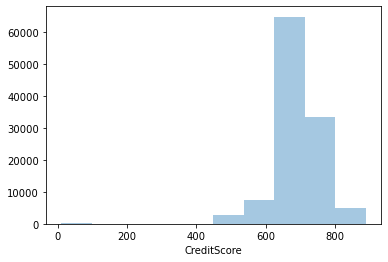

```python
sb.distplot(loan_df.CreditScore.dropna(), kde=False, bins=10);
```

> A brief inspection of creadit socre: the credit score distribution roughly has a bell shape. However, this plot isn't easy to read. We will need to improve the visualization in the following cells. Most of the credit scores are between the range fron 400 to 900.

```python
# Take a brief look basic statistics
loan_df['CreditScore'].describe()
```

```
count   113346.00
mean       695.07
std         66.46
min          9.50
25%        669.50
50%        689.50
75%        729.50
max        889.50
Name: CreditScore, dtype: float64
```

```python
#let's find Outliers
loan_df['CreditScore'].quantile([0, 0.1, 0.2, 0.3, 0.4, 0.5, 0.6, 0.7, 0.8, 0.9, 1])
```

```
0.00     9.50
0.10   629.50
0.20   649.50
0.30   669.50
0.40   689.50
0.50   689.50
0.60   709.50
0.70   729.50
0.80   749.50
0.90   769.50
1.00   889.50
Name: CreditScore, dtype: float64
```

```python
(loan_df.CreditScore < 840).sum()
```

```
112540
```

```python
(loan_df.CreditScore > 840).sum()
```

```
806
```

```python
loan_df.CreditScore.mode()
```

```
0   689.50
dtype: float64
```

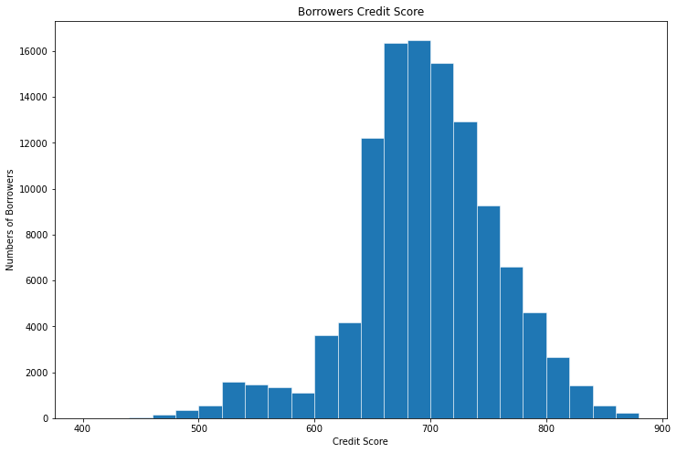

```python
bins = np.arange(400, 900, 20)
plt.figure(figsize=(12, 8))
plt.hist(data = loan_df, x = 'CreditScore',  edgecolor="white", linewidth=0.5, bins=bins);
plt.title('Borrowers Credit Score');
plt.xlabel('Credit Score')
plt.ylabel('Numbers of Borrowers');
plt.show()
```

```python
loan_df.CreditScore.median()
```

```
689.5
```

> The next step: we will investigate the distribution of Prosper Score Prosper Score is a custom risk score built using historical Prosper data. The score ranges from 1-10, with 10 being the best, or lowest risk score. Applicable for loans originated after July 2009.

```python
# take a look of basic statistics
loan_df.ProsperScore.describe()
```

```
count   84853.00
mean        5.95
std         2.38
min         1.00
25%         4.00
50%         6.00
75%         8.00
max        11.00
Name: ProsperScore, dtype: float64
```

```python
# Find Outliers
loan_df['ProsperScore'].quantile([0, 0.1, 0.2, 0.3, 0.4, 0.5, 0.6, 0.7, 0.8, 0.9, .97, 1])
```

```
0.00    1.00
0.10    3.00
0.20    4.00
0.30    4.00
0.40    5.00
0.50    6.00
0.60    7.00
0.70    7.00
0.80    8.00
0.90    9.00
0.97   10.00
1.00   11.00
Name: ProsperScore, dtype: float64
```

```python
# Remove all data where ProsperScore > 10
loan_df = loan_df[loan_df.ProsperScore <11]
```

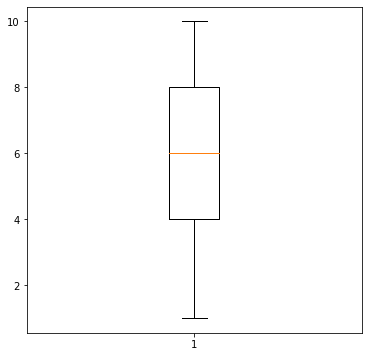

```python
# Confirm no Outliers
plt.figure(figsize=(6, 6))
plt.boxplot(loan_df.ProsperScore);
```

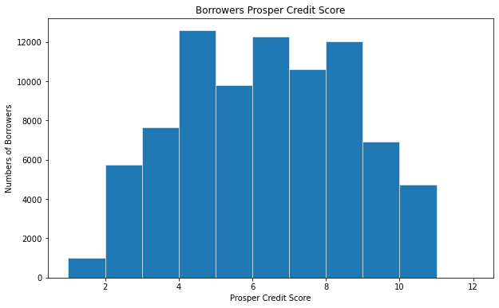

```python
bins = np.arange(1, 13, 1)
plt.figure(figsize=(10, 6))
plt.hist(data = loan_df, x = 'ProsperScore',  edgecolor="white", linewidth=0.5, bins=bins);
plt.title('Borrowers Prosper Credit Score');
plt.xlabel('Prosper Credit Score')
plt.ylabel('Numbers of Borrowers');
plt.show()
```

```python
# Find the mode
loan_df.ProsperScore.mode()
```

```
0   4.00
dtype: float64
```

```python
loan_df.ProsperScore.median()
```

```
6.0
```

> Next, we will take a look of StatedMonthlyIncome

```python
pd.options.display.float_format = '{:.2f}'.format
```

```python
# Simple statistic of
loan_df.StatedMonthlyIncome.describe()
```

```
count     83397.00
mean       5880.22
std        8271.99
min           0.00
25%        3416.67
50%        5000.00
75%        7083.33
max     1750002.92
Name: StatedMonthlyIncome, dtype: float64
```

```python
loan_df.StatedMonthlyIncome.mode()
```

```
0   4166.67
dtype: float64
```

```python
# Find Outliers
loan_df['StatedMonthlyIncome'].quantile([0, 0.1, 0.2, 0.3, 0.4, 0.5, 0.6, 0.7, 0.8, 0.9, .97, 1])
```

```
0.00         0.00
0.10      2108.33
0.20      2916.67
0.30      3500.00
0.40      4166.67
0.50      4666.67
0.60      5416.67
0.70      6250.00
0.80      7500.00
0.90      9750.00
0.97     14166.67
1.00   1750002.92
Name: StatedMonthlyIncome, dtype: float64
```

```python
loan_df.StatedMonthlyIncome.median()
```

```
4666.666667
```

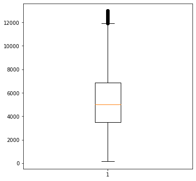

```python
# Find Outliers
plt.figure(figsize=(6, 6))
plt.boxplot(loan_df.StatedMonthlyIncome);
```

```python
(loan_df.StatedMonthlyIncome >13000).sum()
```

```
4415
```

```python
#remove all the data entry where income > 13000
loan_df = loan_df[loan_df.StatedMonthlyIncome <13000]
```

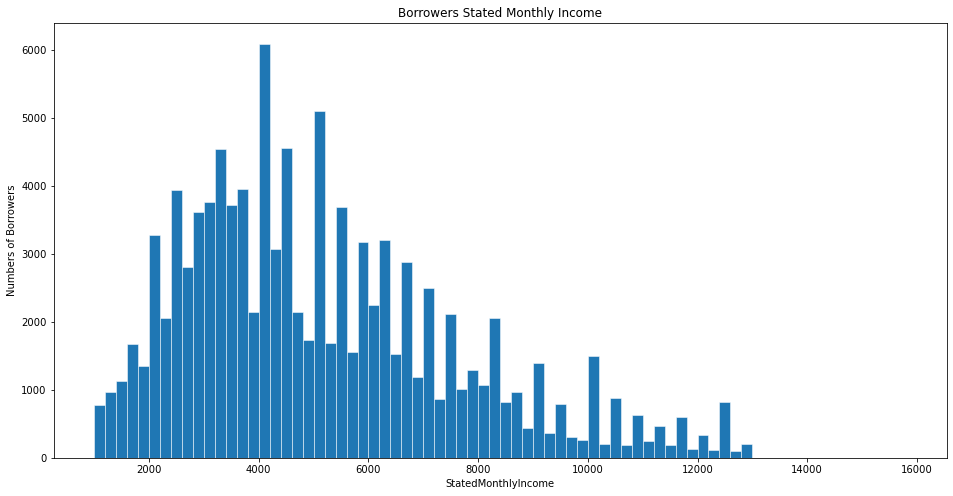

```python
bins = np.arange(1000, 16000, 200)
plt.figure(figsize=(16, 8))
plt.hist(data = loan_df, x = 'StatedMonthlyIncome',  edgecolor="white", linewidth=0.5, bins=bins);
plt.title('Borrowers Stated Monthly Income');
plt.xlabel('StatedMonthlyIncome')
plt.ylabel('Numbers of Borrowers');
plt.show()
```

> The distribution of Stated Monthly income is positively/right skewed, where the Mean is greater than Median!

> Next, we will take a look of EstimatedLoss

```python
loan_df.EstimatedLoss.describe()
```

```
count   81202.00
mean        0.08
std         0.05
min         0.00
25%         0.04
50%         0.07
75%         0.11
max         0.37
Name: EstimatedLoss, dtype: float64
```

```python
loan_df.EstimatedLoss.mode()
```

```
0   0.17
dtype: float64
```

```python
loan_df.EstimatedLoss.median()
```

```
0.0724
```

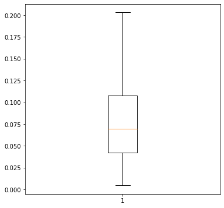

```python
# Find Outliers
plt.figure(figsize=(6, 6))
plt.boxplot(loan_df.EstimatedLoss);
```

```python
# Remove outliers
loan_df = loan_df[loan_df.EstimatedLoss <0.23]
```

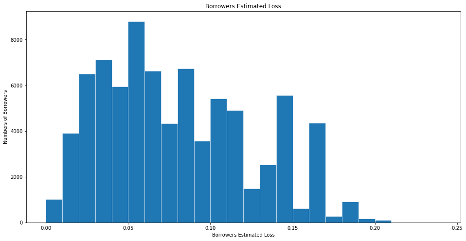

```python
bins = np.arange(0, 0.25, 0.01)
plt.figure(figsize=(16, 8))
plt.hist(data = loan_df, x = 'EstimatedLoss',  edgecolor="white", linewidth=0.5, bins=bins);
plt.title('Borrowers Estimated Loss');
plt.xlabel('Borrowers Estimated Loss')
plt.ylabel('Numbers of Borrowers');
plt.show()
```

```python
loan_df.EstimatedReturn.describe()
```

```
count   80872.00
mean        0.10
std         0.03
min        -0.03
25%         0.07
50%         0.09
75%         0.12
max         0.28
Name: EstimatedReturn, dtype: float64
```

```python
loan_df.EstimatedReturn.median()
```

```
0.0926
```

```python
# Find Outliers
loan_df['EstimatedReturn'].quantile([0, 0.1, 0.2, 0.3, 0.4, 0.5, 0.6, 0.7, 0.8, 0.9, .97, 1])
```

```
0.00   -0.03
0.10    0.06
0.20    0.07
0.30    0.08
0.40    0.09
0.50    0.09
0.60    0.10
0.70    0.11
0.80    0.12
0.90    0.14
0.97    0.15
1.00    0.28
Name: EstimatedReturn, dtype: float64
```

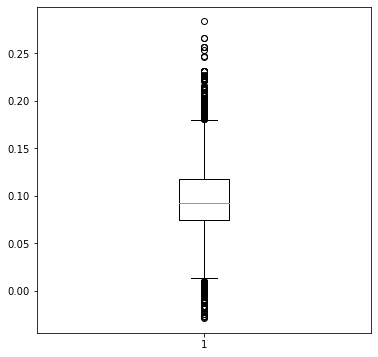

```python
# Find Outliers
plt.figure(figsize=(6, 6))
plt.boxplot(loan_df.EstimatedReturn);
```

```python
# Get rid of the outliers

loan_df = loan_df[loan_df.EstimatedReturn <0.24]
```

```python
loan_df.EstimatedReturn.mode()
```

```
0   0.12
dtype: float64
```

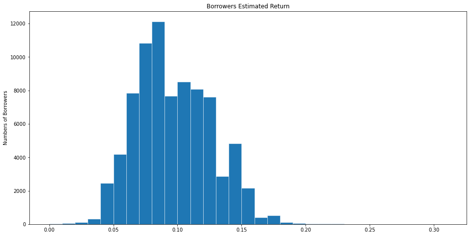

```python
bins = np.arange(0, 0.32, 0.01)
plt.figure(figsize=(16, 8))
plt.hist(data = loan_df, x = 'EstimatedReturn',  edgecolor="white", linewidth=0.5, bins=bins);
plt.title('Borrowers Estimated Return');
plt.ylabel('Numbers of Borrowers');
plt.show()
```

> Next, we will take a look of CurrentCreditLines

```python
loan_df.CurrentCreditLines.mode()
```

```
0   8.00
dtype: float64
```

```python
loan_df.CurrentCreditLines.median()
```

```
10.0
```

```python
loan_df.CurrentCreditLines.describe()
```

```
count   80863.00
mean       10.37
std         5.24
min         0.00
25%         7.00
50%        10.00
75%        13.00
max        59.00
Name: CurrentCreditLines, dtype: float64
```

```python
# Find Outliers
loan_df['CurrentCreditLines'].quantile([0, 0.1, 0.2, 0.3, 0.4, 0.5, 0.6, 0.7, 0.8, 0.9, 0.95, 0.97, 1])
```

```
0.00    0.00
0.10    5.00
0.20    6.00
0.30    7.00
0.40    8.00
0.50   10.00
0.60   11.00
0.70   12.00
0.80   14.00
0.90   17.00
0.95   20.00
0.97   22.00
1.00   59.00
Name: CurrentCreditLines, dtype: float64
```

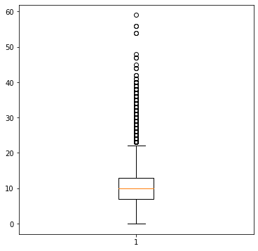

```python
# Find Outliers
plt.figure(figsize=(6, 6))
plt.boxplot(loan_df.CurrentCreditLines);
```

```python
# Get rid of the outliers

loan_df = loan_df[loan_df.CurrentCreditLines < 30]
```

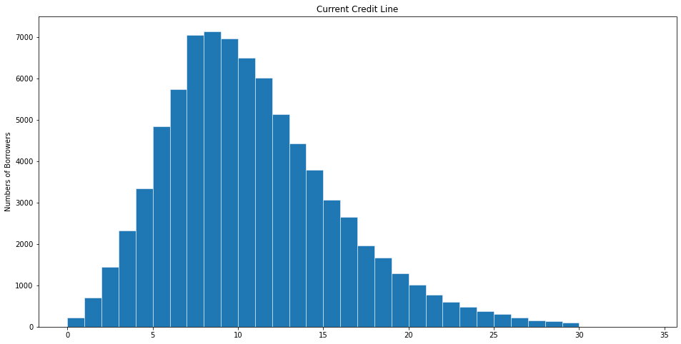

```python
bins = np.arange(0, 35, 1)
plt.figure(figsize=(16, 8))
plt.hist(data = loan_df, x = 'CurrentCreditLines',  edgecolor="white", linewidth=0.5, bins=bins);
plt.title('Current Credit Line');
plt.ylabel('Numbers of Borrowers');
plt.show()
```

> The distribution of CurrentCreditLines looks approximately nomral, where mean equals mean 10.37 meidan equals 10, it skews slightly to the right

> Next we will take a look of OpenCreditLines

```python
loan_df.OpenCreditLines.describe()
```

```
count   80491.00
mean        9.31
std         4.65
min         0.00
25%         6.00
50%         9.00
75%        12.00
max        29.00
Name: OpenCreditLines, dtype: float64
```

```python
loan_df.OpenCreditLines.mode()
```

```
0   7.00
dtype: float64
```

```python
loan_df.OpenCreditLines.median()
```

```
9.0
```

```python
# Find the outliers
loan_df['OpenCreditLines'].quantile([0, 0.1, 0.2, 0.3, 0.4, 0.5, 0.6, 0.7, 0.8, 0.9, 0.95, 0.97, 1])
```

```
0.00    0.00
0.10    4.00
0.20    5.00
0.30    7.00
0.40    8.00
0.50    9.00
0.60   10.00
0.70   11.00
0.80   13.00
0.90   16.00
0.95   18.00
0.97   20.00
1.00   29.00
Name: OpenCreditLines, dtype: float64
```

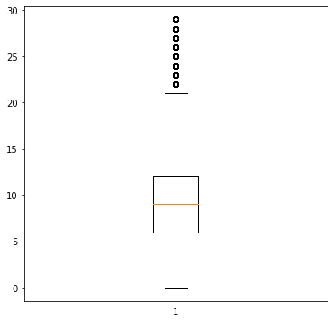

```python
# Find Outliers
plt.figure(figsize=(6, 6))
plt.boxplot(loan_df.OpenCreditLines);
```

```python
loan_df = loan_df[loan_df.OpenCreditLines < 24]
```

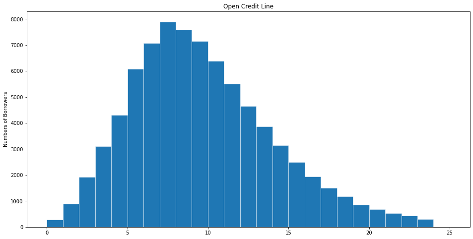

```python
bins = np.arange(0, 26, 1)
plt.figure(figsize=(16, 8))
plt.hist(data = loan_df, x = 'OpenCreditLines',  edgecolor="white", linewidth=0.5, bins=bins);
plt.title('Open Credit Line');
plt.ylabel('Numbers of Borrowers');
plt.show()
```

> The distribuation has Mean: 9.31, Median: 9. It skews to the right slightly.

> Next, we will take a look of DebtToIncomeRatio

```python
loan_df.DebtToIncomeRatio.describe()
```

```
count   73012.00
mean        0.26
std         0.32
min         0.01
25%         0.16
50%         0.23
75%         0.32
max        10.01
Name: DebtToIncomeRatio, dtype: float64
```

```python
loan_df.DebtToIncomeRatio.mode()
```

```
0   0.18
dtype: float64
```

```python
loan_df.DebtToIncomeRatio.median()
```

```
0.23
```

```python
# Find the outliers
loan_df['DebtToIncomeRatio'].quantile([0, 0.1, 0.2, 0.3, 0.4, 0.5, 0.6, 0.7, 0.8, 0.9, 0.95, 0.97, 1])
```

```
0.00    0.01
0.10    0.10
0.20    0.14
0.30    0.17
0.40    0.20
0.50    0.23
0.60    0.26
0.70    0.30
0.80    0.35
0.90    0.42
0.95    0.49
0.97    0.54
1.00   10.01
Name: DebtToIncomeRatio, dtype: float64
```

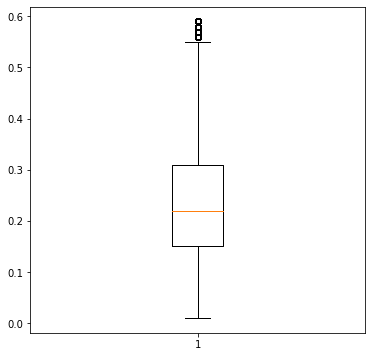

```python
# Find Outliers
plt.figure(figsize=(6, 6))
plt.boxplot(loan_df.DebtToIncomeRatio);
```

```python
loan_df = loan_df[loan_df.DebtToIncomeRatio < 0.6]
```

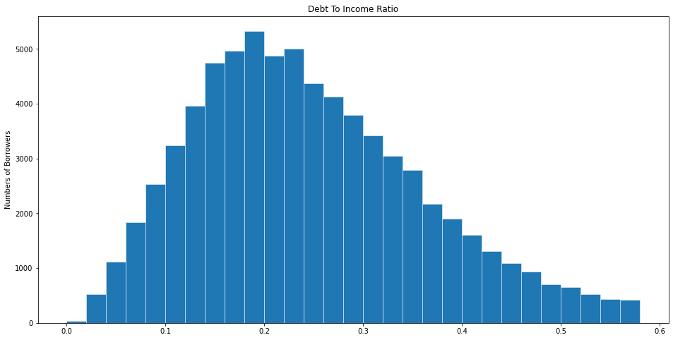

```python
bins = np.arange(0, 0.6, 0.02)
plt.figure(figsize=(16, 8))
plt.hist(data = loan_df, x = 'DebtToIncomeRatio',  edgecolor="white", linewidth=0.5, bins=bins);
plt.title('Debt To Income Ratio');
plt.ylabel('Numbers of Borrowers');
plt.show()
```

> The distribution of debt to income ratio is right-skewed, with mean equals to 0.25 and median 0.23 Next we will take a look of RevolvingCreditBalance

```python
loan_df.RevolvingCreditBalance.describe()
```

```
count    71593.00
mean     15694.86
std      24266.60
min          0.00
25%       3717.00
50%       8840.00
75%      18579.00
max     999165.00
Name: RevolvingCreditBalance, dtype: float64
```

```python
loan_df.RevolvingCreditBalance.mode()
```

```
0   0.00
dtype: float64
```

```python
# Find the outliers
loan_df['RevolvingCreditBalance'].quantile([0, 0.1, 0.2, 0.3, 0.4, 0.5, 0.6, 0.7, 0.8, 0.9, 0.95, 0.97, 1])
```

```
0.00        0.00
0.10      959.00
0.20     2771.00
0.30     4633.60
0.40     6502.80
0.50     8840.00
0.60    11770.00
0.70    15824.80
0.80    22275.60
0.90    35379.60
0.95    50964.80
0.97    67749.48
1.00   999165.00
Name: RevolvingCreditBalance, dtype: float64
```

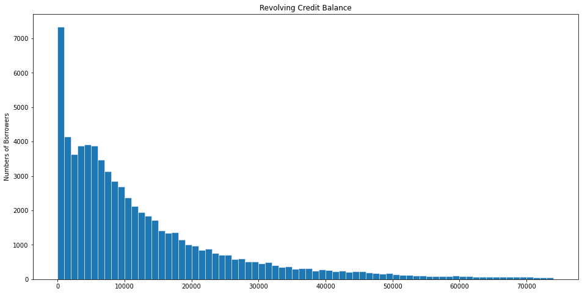

```python
bins = np.arange(0, 75000,1000)
plt.figure(figsize=(16, 8))
plt.hist(data = loan_df, x = 'RevolvingCreditBalance',  edgecolor="white", linewidth=0.5, bins=bins);
plt.title('Revolving Credit Balance');
plt.ylabel('Numbers of Borrowers');
plt.show()
```

> The distribution of RevolvingCreditBalance is right-skewed with the mode of 0. Looks like that most of our borrowers are in good financial situation.

> Next we will take a look of LoanOriginalAmount

```python
loan_df.LoanOriginalAmount.describe()
```

```
count   71593.00
mean     9039.39
std      6156.65
min      1000.00
25%      4000.00
50%      7500.00
75%     13000.00
max     35000.00
Name: LoanOriginalAmount, dtype: float64
```

```python
loan_df.LoanOriginalAmount.mode()
```

```
0    4000
dtype: int64
```

```python
# Find the outliers
loan_df['LoanOriginalAmount'].quantile([0, 0.1, 0.2, 0.3, 0.4, 0.5, 0.6, 0.7, 0.8, 0.9, 0.95, 0.97, 1])
```

```
0.00    1000.00
0.10    2700.00
0.20    4000.00
0.30    4000.00
0.40    5500.00
0.50    7500.00
0.60   10000.00
0.70   11000.00
0.80   15000.00
0.90   16000.00
0.95   20000.00
0.97   25000.00
1.00   35000.00
Name: LoanOriginalAmount, dtype: float64
```

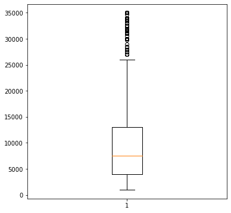

```python
# Find Outliers
plt.figure(figsize=(6, 6))
plt.boxplot(loan_df.LoanOriginalAmount);
```

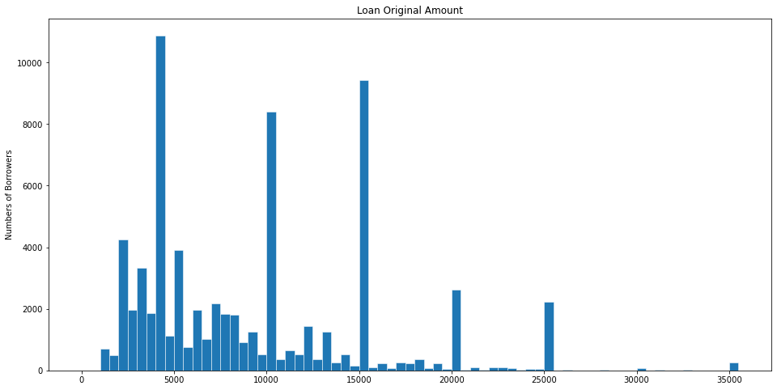

```python
bins = np.arange(0, 36000,500)
plt.figure(figsize=(16, 8))
plt.hist(data = loan_df, x = 'LoanOriginalAmount',  edgecolor="white", linewidth=0.5, bins=bins);
plt.title('Loan Original Amount');
plt.ylabel('Numbers of Borrowers');
plt.show()
```

> Next, we will take a look of LP_NetPrincipalLoss

```python
loan_df.LP_NetPrincipalLoss.describe()
```

```
count   71593.00
mean      335.28
std      1629.44
min      -437.68
25%         0.00
50%         0.00
75%         0.00
max     24740.46
Name: LP_NetPrincipalLoss, dtype: float64
```

```python
loan_df.LP_NetPrincipalLoss.mode()
```

```
0   0.00
dtype: float64
```

```python
# Find the outliers
loan_df['LP_NetPrincipalLoss'].quantile([0, 0.1, 0.2, 0.3, 0.4, 0.5, 0.6, 0.7, 0.8, 0.9, 0.95, 0.97, 1])
```

```
0.00    -437.68
0.10       0.00
0.20       0.00
0.30       0.00
0.40       0.00
0.50       0.00
0.60       0.00
0.70       0.00
0.80       0.00
0.90       0.00
0.95    2388.68
0.97    3882.41
1.00   24740.46
Name: LP_NetPrincipalLoss, dtype: float64
```

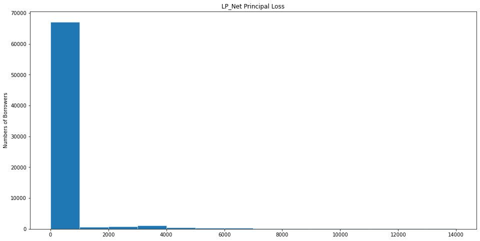

```python
bins = np.arange(0, 15000,1000)
plt.figure(figsize=(16, 8))
plt.hist(data = loan_df, x = 'LP_NetPrincipalLoss',  edgecolor="white", linewidth=0.5, bins=bins);
plt.title('LP_Net Principal Loss');
plt.ylabel('Numbers of Borrowers');
plt.show()
```

> For most of the loan, we don't have any net loss, the mode of LP_NetPrinciplaLoss is 0. The are some cases where the loss amount is around 4000 - 7000, but overall we don't have that many bad cases.

```python
loan_df.info()
```

```
<class 'pandas.core.frame.DataFrame'>
Int64Index: 71593 entries, 1 to 113936
Data columns (total 29 columns):
 #   Column                      Non-Null Count  Dtype
---  ------                      --------------  -----
 0   ListingKey                  71593 non-null  object
 1   ListingNumber               71593 non-null  int64
 2   ListingCreationDate         71593 non-null  object
 3   CreditGrade                 0 non-null      object
 4   ProsperRating (numeric)     71593 non-null  float64
 5   ProsperRating (Alpha)       71593 non-null  object
 6   ProsperScore                71593 non-null  float64
 7   Term                        71593 non-null  int64
 8   CreditScoreRangeLower       71593 non-null  float64
 9   CreditScoreRangeUpper       71593 non-null  float64
```

[output cut: 21 more lines]

```python
loan_df.BorrowerRate.describe()
```

```
count   71593.00
mean        0.19
std         0.07
min         0.04
25%         0.14
50%         0.18
75%         0.25
max         0.36
Name: BorrowerRate, dtype: float64
```

```python
loan_df.BorrowerRate.mode()
```

```
0   0.32
dtype: float64
```

```python
loan_df.BorrowerRate.median()
```

```
0.1845
```

```python
# Find the outliers
loan_df['BorrowerRate'].quantile([0, 0.1, 0.2, 0.3, 0.4, 0.5, 0.6, 0.7, 0.8, 0.9, 0.95, 0.97, 1])
```

```
0.00   0.04
0.10   0.10
0.20   0.12
0.30   0.14
0.40   0.16
0.50   0.18
0.60   0.21
0.70   0.24
0.80   0.26
0.90   0.31
0.95   0.32
0.97   0.32
1.00   0.36
Name: BorrowerRate, dtype: float64
```

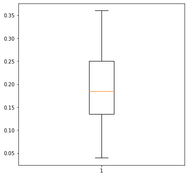

```python
# Find Outliers
plt.figure(figsize=(6, 6))
plt.boxplot(loan_df.BorrowerRate);
```

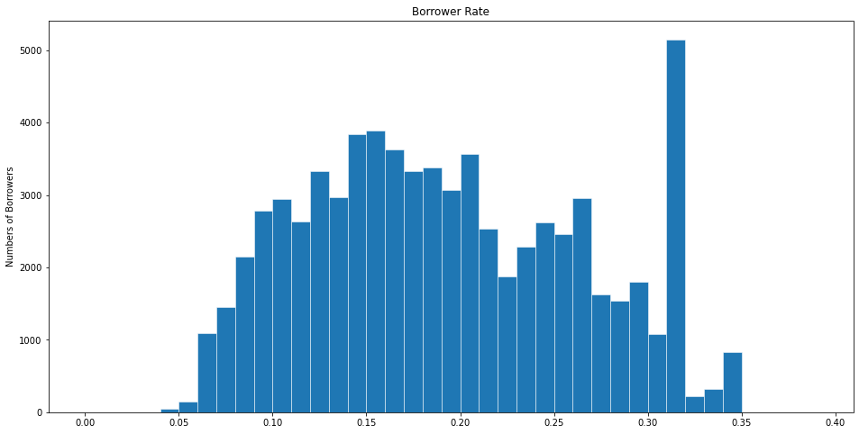

```python
bins = np.arange(0, 0.4,0.01)
plt.figure(figsize=(16, 8))
plt.hist(data = loan_df, x = 'BorrowerRate',  edgecolor="white", linewidth=0.5, bins=bins);
plt.title('Borrower Rate');
plt.ylabel('Numbers of Borrowers');
plt.show()
```

> The distribution is positivly/right skewed.

### Discuss the distribution(s) of your variable(s) of interest. Were there any unusual points? Did you need to perform any transformations?

> CurrentCreditLines I got rid of the outliers whose CurrentCreditLines is bigger than 30. The distribution of CurrentCreditLines looks approximately nomral, where mean equals mean 10.37 meidan equals 10, it skews slightly to the right

> OpenCreditLines The distribuation has Mean: 9.31, Median: 9. It skews to the right slightly.

> DebtToIncomeRatio The distribution of debt to income ratio is right-skewed, with mean equals to 0.25 and median 0.23.

> RevolvingCreditBalance The distribution of RevolvingCreditBalance is right-skewed with the mode of 0. Looks like that most of our borrowers are in good financial situation.

> BorrowerRate Median: 0.1845, mean : 0.19 The distribution is positivly/right skewed.

### Of the features you investigated, were there any unusual distributions? Did you perform any operations on the data to tidy, adjust, or change the form of the data? If so, why did you do this?

> Remove all the data entry where income > 13000 (Outliers)

> I got rid of the outliers whose OpenCreditLines > 24

> I also removed all the Prosper Score >10

> I got rid of the outliers whose OpenCreditLines > 24

## Bivariate Exploration

> In this section, we are going to use Bivariate Exploration to gain more insights of our data

```python
# Select sample data
rand = np.random.choice(loan_df.shape[0], 1000, replace = False)
rand_df = loan_df.reindex(index =rand )
```

```python
rand_df.info()
```

```
<class 'pandas.core.frame.DataFrame'>
Int64Index: 1000 entries, 60656 to 60398
Data columns (total 29 columns):
 #   Column                      Non-Null Count  Dtype
---  ------                      --------------  -----
 0   ListingKey                  603 non-null    object
 1   ListingNumber               603 non-null    float64
 2   ListingCreationDate         603 non-null    object
 3   CreditGrade                 0 non-null      object
 4   ProsperRating (numeric)     603 non-null    float64
 5   ProsperRating (Alpha)       603 non-null    object
 6   ProsperScore                603 non-null    float64
 7   Term                        603 non-null    float64
 8   CreditScoreRangeLower       603 non-null    float64
 9   CreditScoreRangeUpper       603 non-null    float64
```

[output cut: 21 more lines]

```python
#

var = ['ProsperScore','CreditScore','EstimatedLoss','EstimatedReturn','StatedMonthlyIncome','DebtToIncomeRatio','LoanOriginalAmount','BorrowerRate','OpenCreditLines']
```

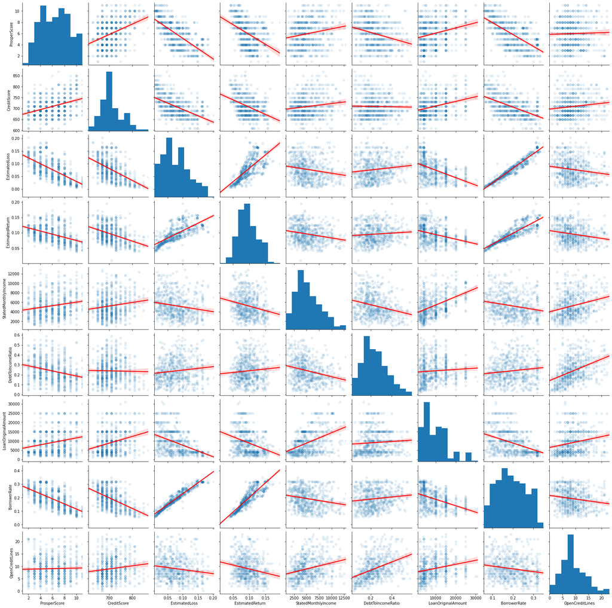

```python
# plot pairplot that gives an overview of
pp = sb.pairplot(data=rand_df, vars=var, kind='reg', plot_kws={'line_kws':{'color':'red'}, 'scatter_kws': {'alpha': 0.1}})
```

```python
loan_df1 = loan_df[['ProsperScore','CreditScore','EstimatedLoss',\
                    'EstimatedReturn','StatedMonthlyIncome','DebtToIncomeRatio',\
                    'LoanOriginalAmount','BorrowerRate','RevolvingCreditBalance','LP_NetPrincipalLoss','OpenCreditLines']]
```

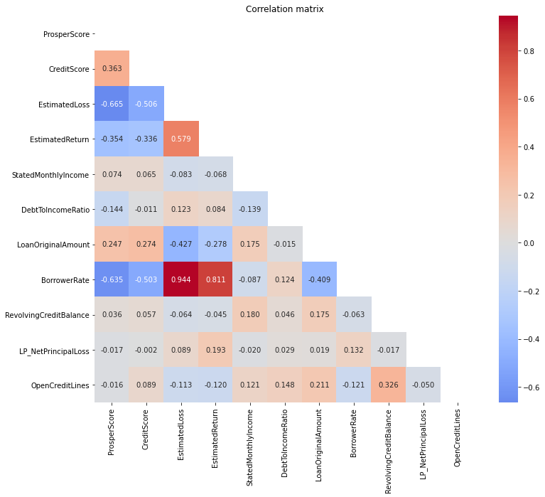

```python
# plot correlation matrix
plt.figure(figsize = [12,10])

mask = np.zeros_like(loan_df1.corr(), dtype=np.bool)
mask[np.triu_indices_from(mask)] = True

sb.heatmap(loan_df1.corr(), annot = True, fmt = '.3f', cmap = 'coolwarm', center = 0, mask=mask)
plt.title('Correlation matrix');
```

### Talk about some of the relationships you observed in this part of the investigation. How did the feature(s) of interest vary with other features in the dataset?

> From the overview of correlations we drew the following observations:

> 1: Loan Originating Amount is positively correlated to Stated Monthly Income. It seems that the higher the monthly income is, the higher the amount people borrow.

> 2: One interesting thing: both estimated return and loss are negativly correlated to Loan originating amount.

> 3: It looks like borrowers with higher credit scores are able to borrow higher amounts. Credit-Score is positively corrleated to Loan Orginal Amount

> 4: Both Prosper Score and Credit Score are negativly correlated to Expected loss and Expected Return

> 5: Borrower Rate has strong positive correlations with Estimated Loss and Return.

> 6: Borrowers with higher Credit scores and Prosper Scores have lower borrower rate.

### Did you observe any interesting relationships between the other features (not the main feature(s) of interest)?

> Stated Monthly income is positivly correlated with Revolving Credit Balance. It seems that people with higher wage tend to have more revolving credit/credit card debt. It's pretty interesting to see that people tend to consume more instead of saving up when they earn higher wage

## Multivariate Exploration

> Create plots of three or more variables to investigate your data even further. Make sure that your investigations are justified, and follow from your work in the previous sections.

```python
# The relationship between BorrowerRate and Credit scores & Prosper Scores
```

[figure not shown]

```python
# Scatter plot : The relationship between BorrowerRate and Credit scores & Prosper Scores
plt.figure(figsize = [12,10])
plt.scatter(data=loan_df, x='ProsperScore', y='BorrowerRate', c='CreditScore', cmap='twilight_shifted_r', alpha=0.05);
cbar = plt.colorbar(label='Credit Score')
cbar.solids.set(alpha=1)
plt.title('BorrowerRate vs ProsperScore & Credit Score');
plt.xlabel('Prosper Score')
plt.ylabel('BorrowerRate');
```

> We can see that the best borrowers with high ProsperScore&Creditscore have lower Borrower Rate. Many borrowers with high Prosper Score can borrowe at rate that is lover than 0.25

> In general borrowers with higher Prosper Score also have high Credit Score.

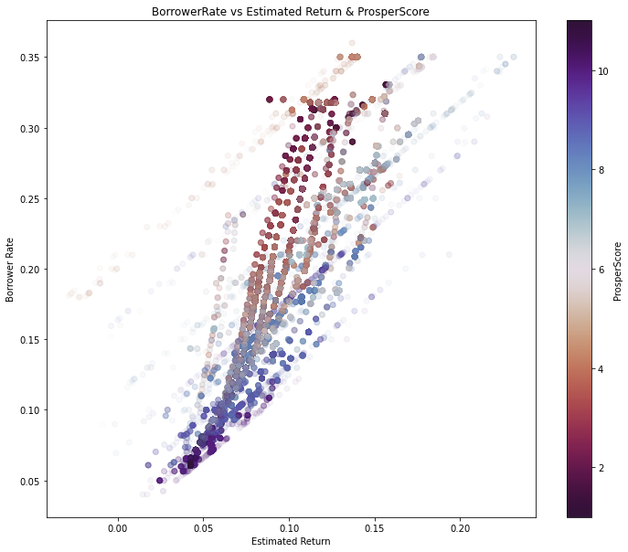

```python
plt.figure(figsize = [12,10])
plt.scatter(data=loan_df, x='EstimatedReturn', y='BorrowerRate', c='ProsperScore', cmap='twilight_shifted_r', alpha=0.05);
cbar = plt.colorbar(label='ProsperScore')
cbar.solids.set(alpha=1)
plt.title('BorrowerRate vs Estimated Return & ProsperScore');
plt.xlabel('Estimated Return')
plt.ylabel('Borrower Rate');
```

> Estimated Return has a strong positive relationship with borrower rate. And In general, borrower with good Prosper Score can borrow at a lower rate.

[figure not shown]

```python
plt.figure(figsize = [12,10])
plt.scatter(data=loan_df, x='EstimatedLoss', y='BorrowerRate', c='CreditScore', cmap='twilight_shifted_r', alpha=0.05);
cbar = plt.colorbar(label='CreditScore')
cbar.solids.set(alpha=1)
plt.title('BorrowerRate vs Estimated Loss & CreditScore');
plt.xlabel('Estimated Loss')
plt.ylabel('Borrower Rate');
```

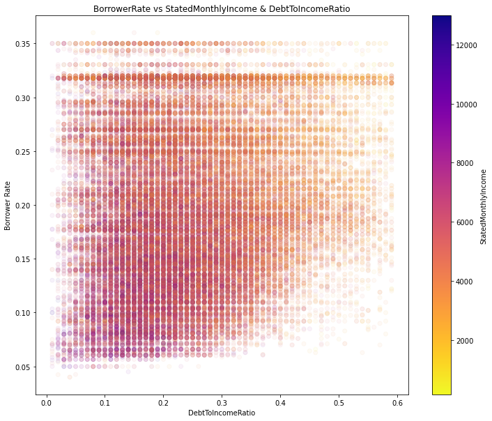

```python
plt.figure(figsize = [12,10])
plt.scatter(data=loan_df, x='DebtToIncomeRatio', y='BorrowerRate', c='StatedMonthlyIncome', cmap='plasma_r', alpha=0.05);
cbar = plt.colorbar(label='StatedMonthlyIncome')
cbar.solids.set(alpha=1)
plt.title('BorrowerRate vs StatedMonthlyIncome & DebtToIncomeRatio');
plt.xlabel('DebtToIncomeRatio')
plt.ylabel('Borrower Rate');
```

> In general, Borrower with higher monthly income have lower DebtToIncomeRatio, they also can borrow at a lower rate.

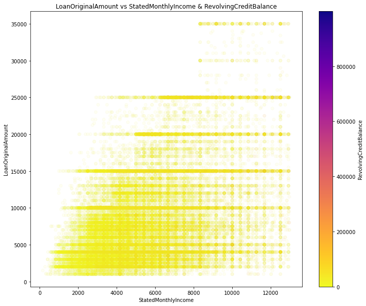

```python
plt.figure(figsize = [12,10])
plt.scatter(data=loan_df, x='StatedMonthlyIncome', y='LoanOriginalAmount', c='RevolvingCreditBalance', cmap='plasma_r', alpha=0.05);
cbar = plt.colorbar(label='RevolvingCreditBalance')
cbar.solids.set(alpha=1)
plt.title('LoanOriginalAmount vs StatedMonthlyIncome & RevolvingCreditBalance');
plt.xlabel('StatedMonthlyIncome')
plt.ylabel('LoanOriginalAmount');
```

> Borrowers with higher monthly income generally can borrower higher amount.

```python
loan_df1.to_csv('loan_final.csv')
```

### Talk about some of the relationships you observed in this part of the investigation. Were there features that strengthened each other in terms of looking at your feature(s) of interest?

> In this section, I used Correlation matrix and Scatter plot to explore the relationship between variables.

> It seems that both Prosper score and Credit score have strong negative relationship with Borrower Rate. Borrowers with higher Prosper score and Credit score are able to borrow with lower cost (borrower rate).

> Loan Original amount is negatively correlated with borrower rate. It seems that the bigger the amount a borrower borrow, the lower the rate.

> Loan Original amount is positively correlated with Prosper score and credit score. It seems that borrowers with better scores are able to borrow bigger amount.

### Were there any interesting or surprising interactions between features?

> One thing interesting is that OpenCreditLines has a weak positively correlated relationship with StatedMonthlyIncome and LoanOriginalAmount. In this analysis we didn’t run any regression and test it. But it might because people with higher income, in general has higher creditcard limits.

> At the end of your report, make sure that you export the notebook as an html file from the `File > Download as... > HTML` menu. Make sure you keep track of where the exported file goes, so you can put it in the same folder as this notebook for project submission. Also, make sure you remove all of the quote-formatted guide notes like this one before you finish your report!